# Sarek Paper

# 3 Resource Usage

Here all values are used, to sanity-check if the same amount of PCUs/Memory has been requested. So the stat marker are not indicative here.

## 3.1 CPU Usage

### 3.1.1 Preprocessing

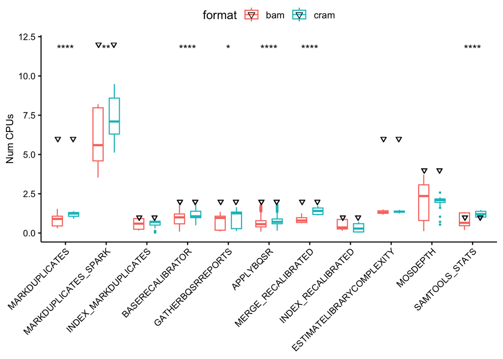

### 3.1.2 Variantcalling

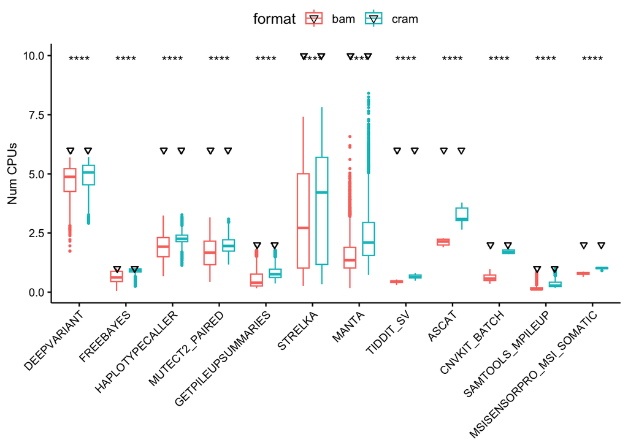

## 3.2 Memory Usage

### 3.2.1 Peak RSS

#### 3.2.1.1 Preprocessing

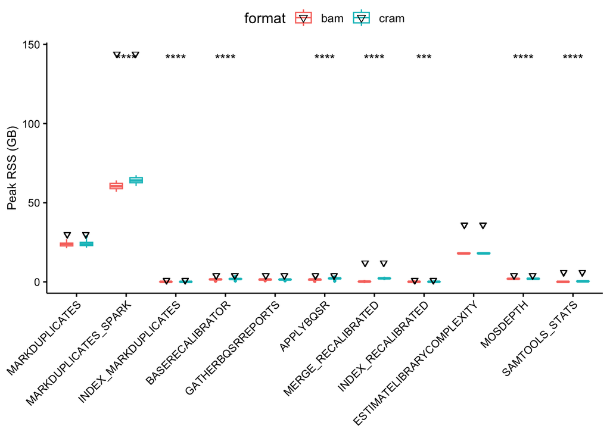

#### 3.2.1.2 Variant calling

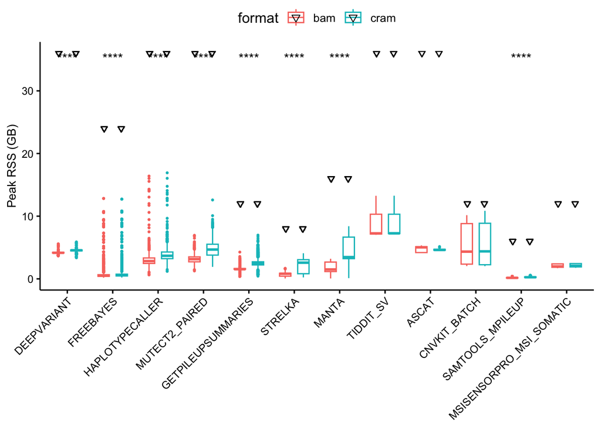

### 3.2.2 Vmem

#### 3.2.2.1 Preprocessing

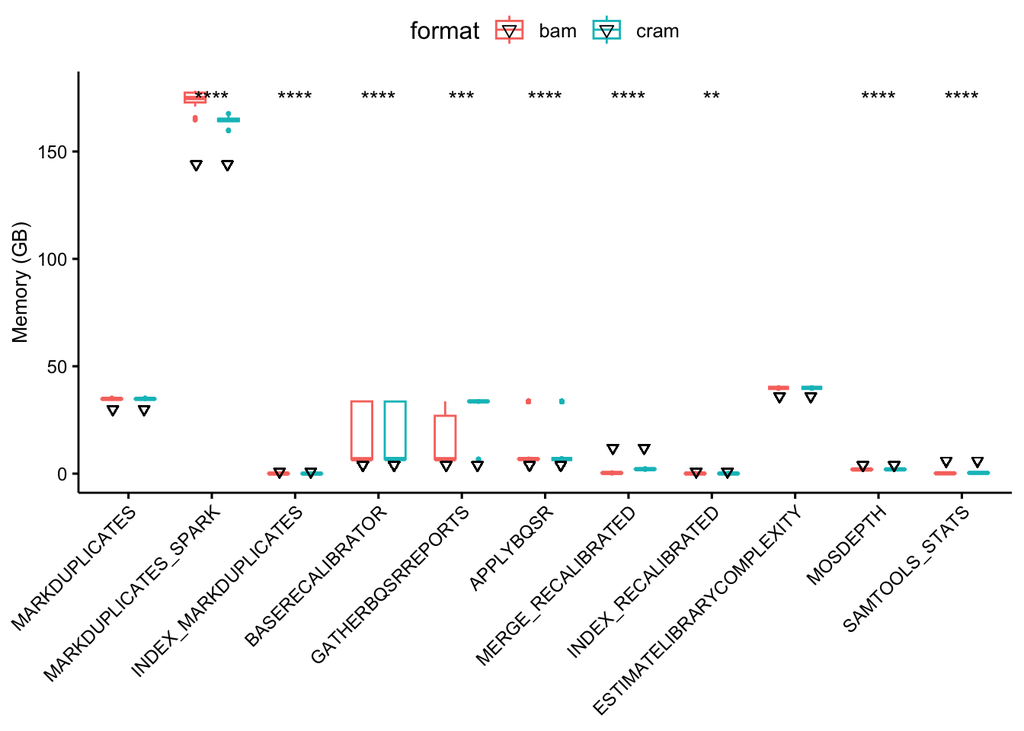

#### 3.2.2.2 Variantcalling

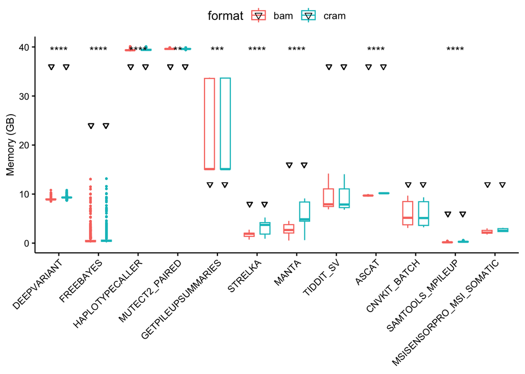

### 3.2.3 Peak Vmem

#### 3.2.3.1 Preprocessing

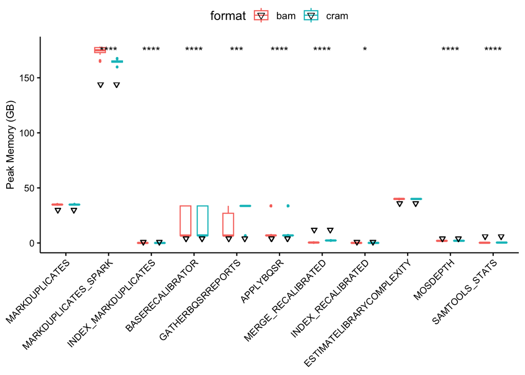

#### 3.2.3.2 Variant calling

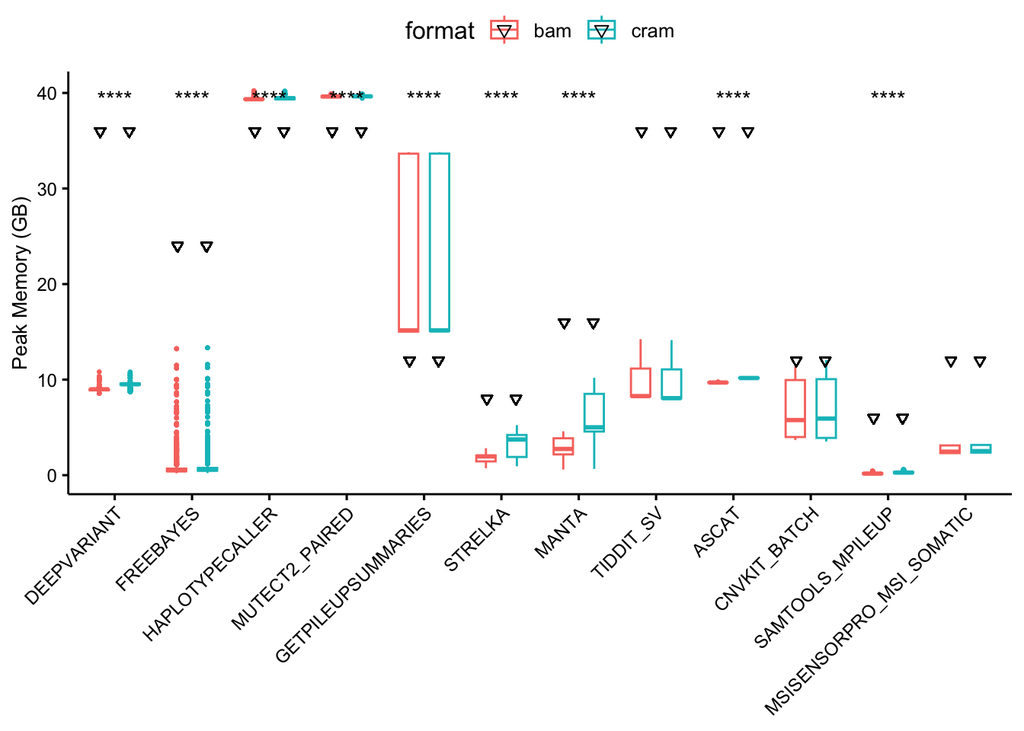

## 3.3 Real time

### 3.3.1 Preprocessing

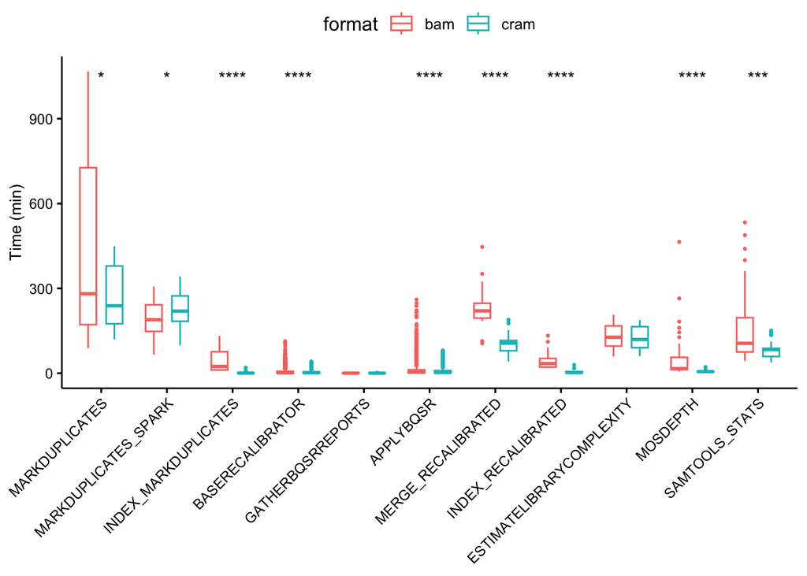

### 3.3.2 Variant calling

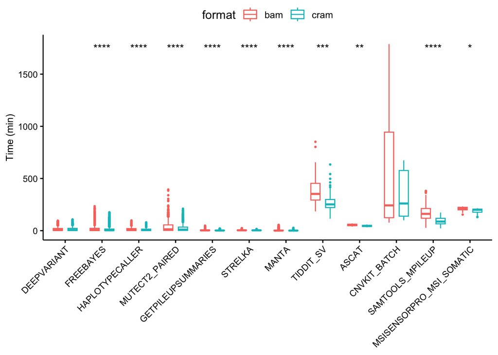

## 3.4 Combine compute resource plots

### 3.4.1 Preprocessing

Here, the data is filtered:

For each process that support scatter/gather, i.e. APPLYBQSR, the process with the longest runtime is kept, reducing the datapoint per sample & repetition to one. For all processes, the three replicates for each data type are combined by taking the avg runtime, the max cpu & memory usage over each group, further reducint the data points per box plot from 30 to 10.

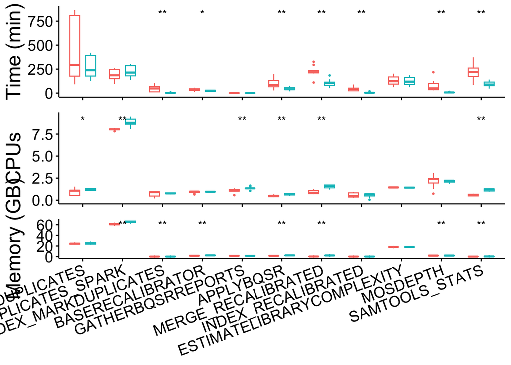

### 3.4.2 Preprocessing-reduced (Paper)

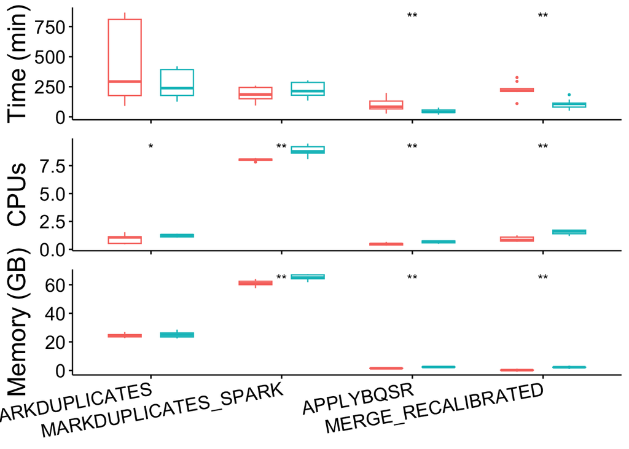

### 3.4.3 Variant calling

[figure not shown]

## 3.5 Storage usage (cumulative)

Sum over all samples, if scatter/gather then all sub-processes have been summed up.

### 3.5.2 Preprocessing

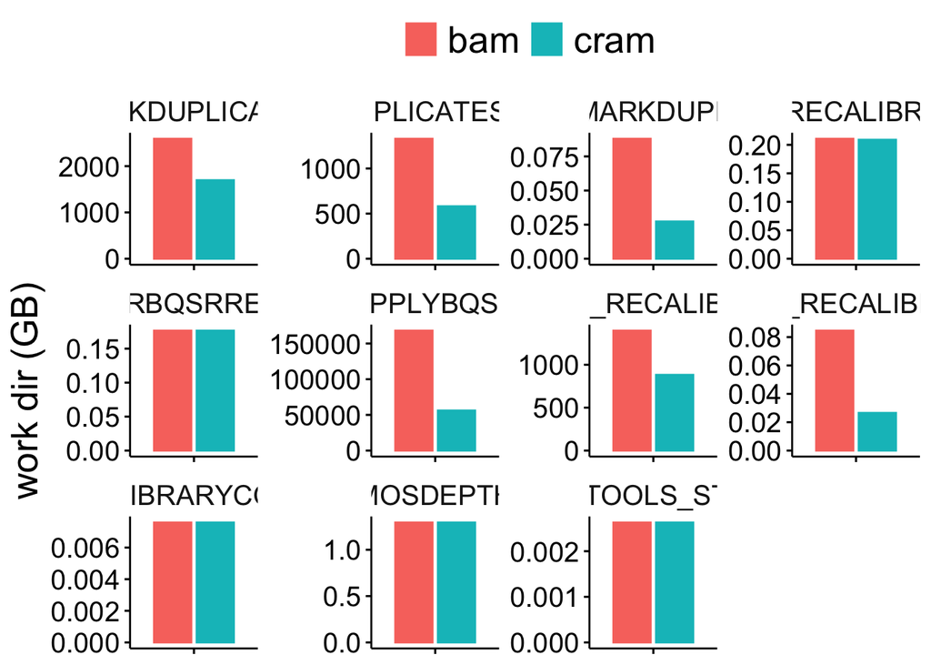

### 3.5.3 Variantcalling

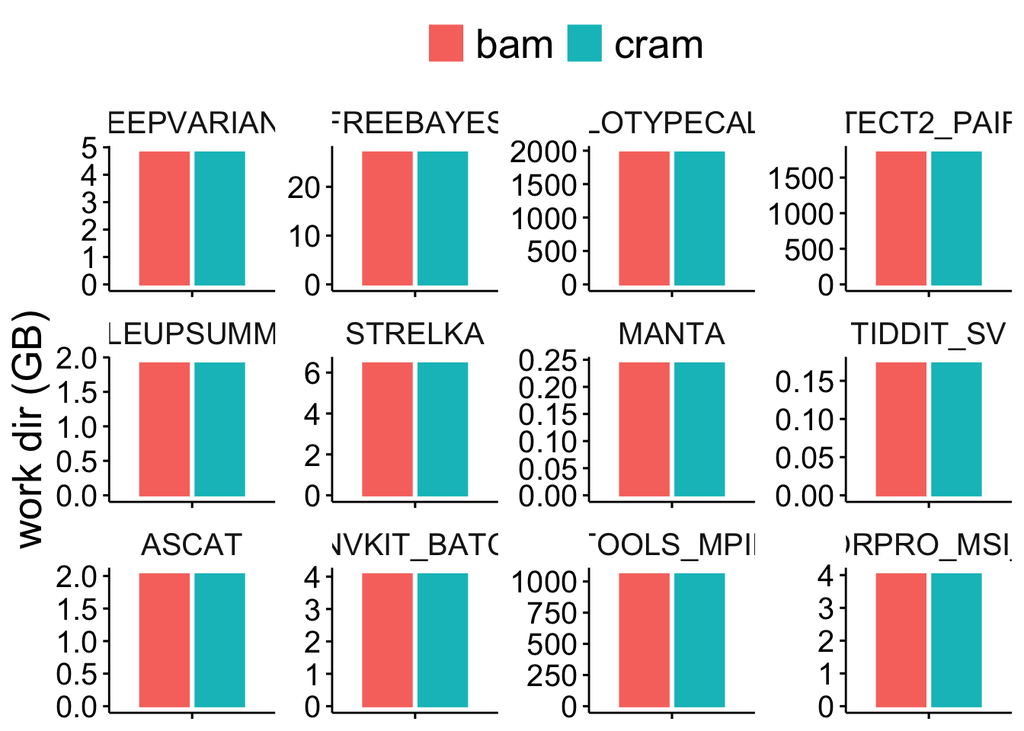

## 3.6 Summary: Combine Storage and compute resources

### 3.6.1 Paper main text

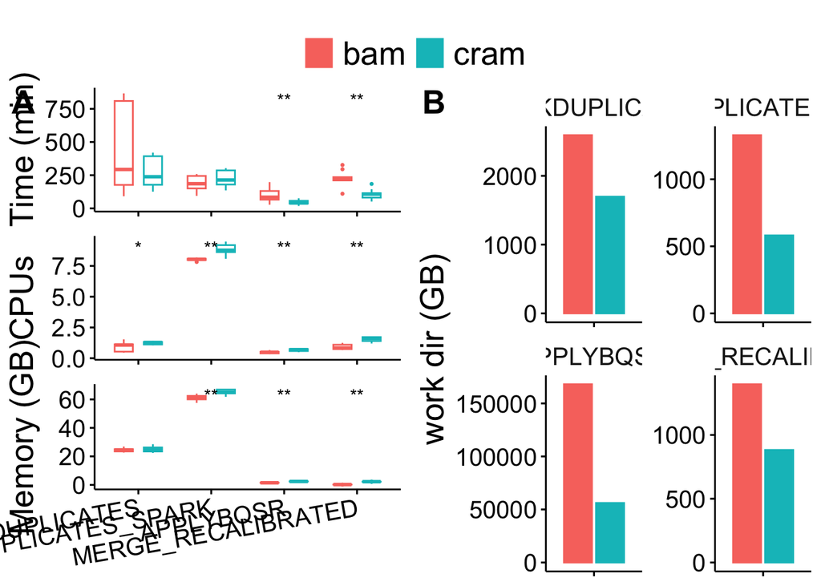

### 3.6.2 Preprocessing

[figure not shown]

### 3.6.3 Variant calling

[figure not shown]

# 4 Methods

Package versions:

```
##  ggnewscale   ggpattern       tidyr viridisLite      ggpubr  kableExtra
##     "0.4.8"     "1.0.1"     "1.3.0"     "0.4.1"     "0.6.0"     "1.3.4"
##       knitr     cowplot     ggplot2     forcats   patchwork       dplyr
##      "1.42"     "1.1.1"     "3.4.0"     "1.0.0"     "1.1.2"     "1.1.0"
```